# Generating and modifying matrices

Thomas Guillerme

2022-03-24

#### Loading the package and functions

```r
## The latest version of devtools
if(!require(devtools)) install.packages("devtools")

## The latest version of dispRity
if(!require(dispRity)) install_github("TGuillerme/dispRity")
## The cran version of diversitree
if(!require(diversitree)) install_github("richfitz/diversitree")
## Loading the functions not included in dispRity
source("../../Functions/modify.matrix.R")

## Seed for repeatability
set.seed(123)
```

# Generating the matrix

Before anything, let’s set our simulation variables: the number of taxa and the number of characters:

```r
## Number of taxa
ntaxa <- 25

## Number of characters
ncharacters <- 100
```

## Generating the tree

First, we need to generate a realistic birth death tree upon which to simulate our characters. For that we will need a function for randomly sampling our birth/death rates from a uniform (0,1) distribution while making sure that the death rate is lower that the birth rate:

```r
sample.birth.death <- function() {
    birth <- runif(min = 0, max = 1, 1)
    death <- runif(min = 0, max = birth, 1)
    return(c(birth, death))
}
```

Then let’s generate the tree. We add a while loop to the algorithm to make sure that the tree actually generate properly. For example, if the birth rate sampled is 0, no tree will be generated!

```r
tree <- NULL
## The birth-death parameters
(birth_death <- sample.birth.death())
```

```
## [1] 0.2875775 0.2266988
```

```r
## Generate the tree
while(is.null(tree)) {
    tree <- tree.bd(birth_death, max.taxa = ntaxa)
}
```

```r
## Remove the $node labels (bugging for some reason)
tree$node.label <- NULL

## Make the first taxa (arbitrarily) the outgroup
tree$tip.label[[1]] <- "outgroup"
tree <- root(tree, "outgroup", resolve.root = TRUE)
```

And this is what our tree looks like

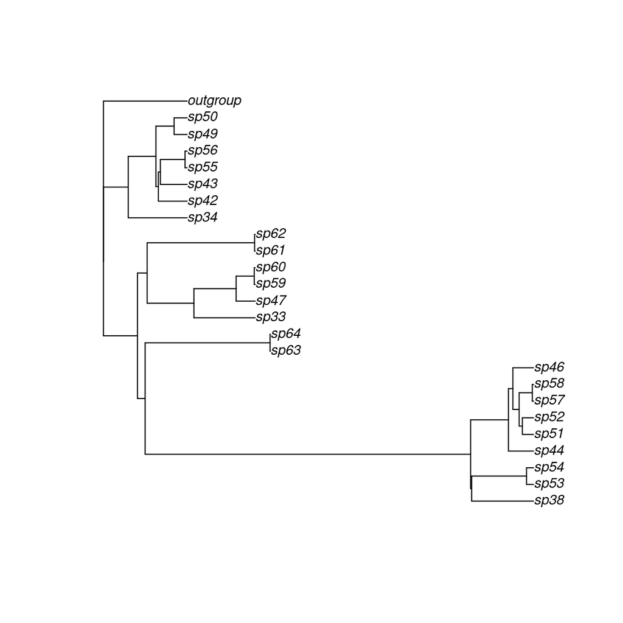

```r
plot(tree, cex = 0.8)
```

## Generating the matrix

```r
## Simulate a matrix
matrix_norm <- sim.morpho(tree, ncharacters, states = c(0.85, 0.15),
    model = "mixed", rates = c(rgamma, rate = 100, shape = 3),
    invariant = FALSE)

## Resimulate it if the consistency index is too low
while(check.morpho(matrix_norm)[2,] < 0.26) {
    matrix_norm <- sim.morpho(tree, ncharacters, states = c(0.85, 0.15),
        model = "mixed", rates = c(rgamma, rate = 100, shape = 3),
        invariant = FALSE)
}
```

We can also check how realistic our simulated matrix is:

```r
check.morpho(matrix_norm, tree)
```

```
##
## Maximum parsimony        226.0000000
## Consistency index          0.4734513
## Retention index            0.7213115
## Robinson-Foulds distance  28.0000000
```

## Modifying the matrix

We can now maximise, minimise and randomise the character differences from the original matrix (`matrix_norm`).

```r
## Maximising the character difference
matrix_maxi <- modify.matrix(matrix_norm, type = "maximise", threshold = 0.25)
## Minimising the character difference
matrix_mini <- modify.matrix(matrix_norm, type = "minimise", threshold = 0.75)
## Randomising the character difference
matrix_rand <- modify.matrix(matrix_norm, type = "randomise")
```

We can then visualise the modifications by looking at the pairwise character differences:

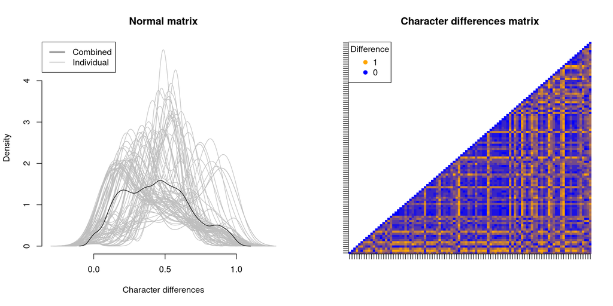

```r
## Character difference
char_diff_matrix_norm <- char.diff(matrix_norm)
par(mfrow = c(1, 2))
## The character difference density (per character)
plot(char_diff_matrix_norm, type = "density", main = "Normal matrix")
## The character difference matrix (pairwise)
plot(char_diff_matrix_norm, type = "matrix")
```

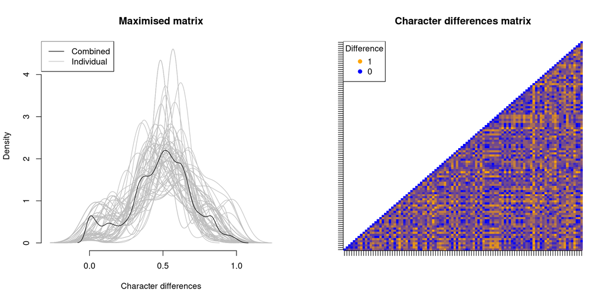

```r
## Character difference
char_diff_matrix_maxi <- char.diff(matrix_maxi[[1]])
par(mfrow = c(1, 2))
## The character difference density (per character)
plot(char_diff_matrix_maxi, type = "density", main = "Maximised matrix")
## The character difference matrix (pairwise)
plot(char_diff_matrix_maxi, type = "matrix")
```

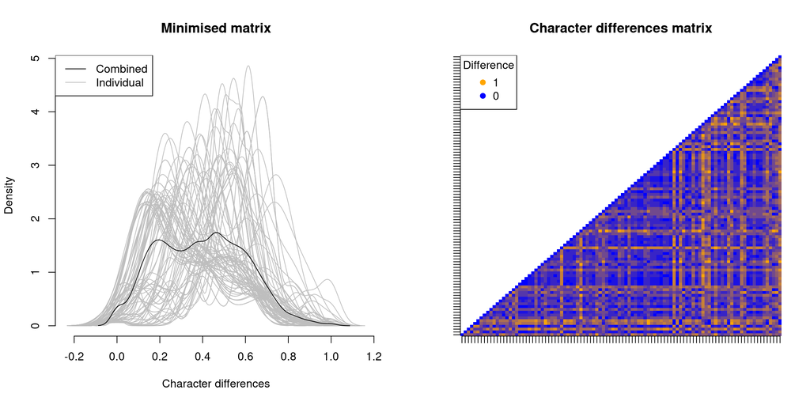

```r
## Character difference
char_diff_matrix_mini <- char.diff(matrix_mini[[1]])
par(mfrow = c(1, 2))
## The character difference density (per character)
plot(char_diff_matrix_mini, type = "density", main = "Minimised matrix")
## The character difference matrix (pairwise)
plot(char_diff_matrix_mini, type = "matrix")
```

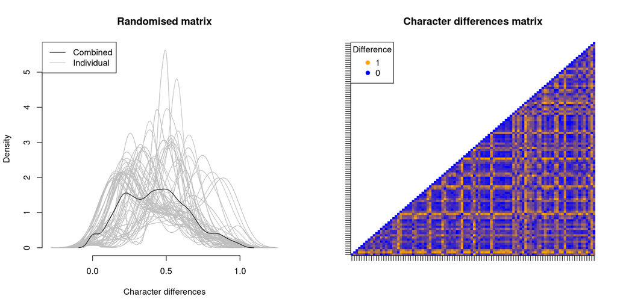

```r
## Character difference
char_diff_matrix_rand <- char.diff(matrix_rand[[1]])
par(mfrow = c(1, 2))
## The character difference density (per character)
plot(char_diff_matrix_rand, type = "density", main = "Randomised matrix")
## The character difference matrix (pairwise)
plot(char_diff_matrix_rand, type = "matrix")
```